# Replication of Study: Transient Spatial Attention Degrades Temporal Resolution by Yeshurun & Levy (2003, Psychological Science)

Insub Kim (insubkim@stanford.edu)

November 25, 2019

##Introduction

Yeshurun and Levy (2003), investigated the effect of spatial attention on visual temporal processes. The authors manipulated observers’ transient spatial attention by using peripheral pre-cueing and measured their temporal resolution by two-flash fusion threshold (ability to discriminate successive two light flashes). Through this investigation, they found that enhanced spatial attention reduced temporal resolution.

I chose this paper because my research interest lies in establishing spatial-temporal model for our visual cortex. Specifically, as this paper investigated the relationship between spatial and temporal visual characteristics, I am hoping that replicating this paper would provide further insights on how attentional factors could contribute to interplays between perceptual domain of space and time. In the long run, I would like to incorporate the effect of attention on temporal processing with its emphasis on foveal and peripheral spatial representation differences.

For this project, each observer’s threshold of temporal resolution will be measured in two different conditions (cued and un-cued). In cued trials, a periphery cue will be presented before the target onset, which indicate the target’s location. While in un-cued trials, neutral cue with no indication of the target’s location will be presented. Therefore, precise control of stimuli presentation timing might be a challenge for the replication project and I am not sure if M-turk can handle stimulus timing as brief as 11 ms.

The original paper had 3 different experiments. However, I am to only replicate experiment 3 for this project and observers will be recruited from Amazon M-turk.

- Github repository: https://github.com/psych251/Yeshurun2003
- Original paper: https://github.com/psych251/Yeshurun2003/tree/master/original_paper
- rPubLink: http://rpubs.com/insubkim/536227
- Reference: Yeshurun, Y., & Levy, L. (2003). Transient spatial attention degrades temporal resolution. Psychological Science, 14(3), 225-231.

##Methods

###Power Analysis

Original effect size is not reported in the original paper. Thus, I aim to get 18 participants following the number of participant reported in the original paper.

###Planned Sample

I will use 18 participants.

###Materials

Two-flash fusion threshold: Measure of temporal resolution. “Two flashes of light were presented successively to the same location, and we determined the minimal interval between the flashes at which they were still perceived as two separate flashes, rather than as a single continuous flash. The shorter this critical interval is, the higher the temporal resolution (e.g., Artieda, Pastor, Lacruz, & Obeso, 1992;Reeves, 1996).”

Target: The target (37-cd/m2 disk with a diameter of 3 degrees) was composed of two flashes of light separated by a brief interval or a single continous flash. “It appeared on a black background at one of 11 possible locations along the horizontal meridian, with eccentricity (distance from the center) ranging from 0 to 16.5 degrees The cue in the cued trials was a 1 X 0.3 degrees green horizontal bar (43 cd/m2) appearing 0.5 degree above the target’s location. In the neutral trials, two 17 x 0.3 degree green horizontal lines appeared above and below the entire display.”

Insturements: 21-inch monitor of a PowerMac G4 computer was used in the original experiment.

###Procedure

Followed the exact procedure as quated from the original article:

“Each trial began with a fixation point followed by the attentional cue. The cue was present until the target’s offset, to prevent confusion between the flickering of the cue and that of the target. The target was presented 94 ms after onset of the cue: On 50% of the trials, two disks appeared, each for 47 ms, separated by a variable interval (interstimulus interval, ISI, of 11–34 ms). On the rest of the trials, a single disk was presented for a duration ranging from 105 to 130 ms. These brief durations ensured that eye movements could not occur between cue onset and target offset (Mayfrank, Kimmig, & Fischer,1987). Each observer viewed 864 trials presented in a randomized order. Both accuracy and reaction time (RT) were recorded.”

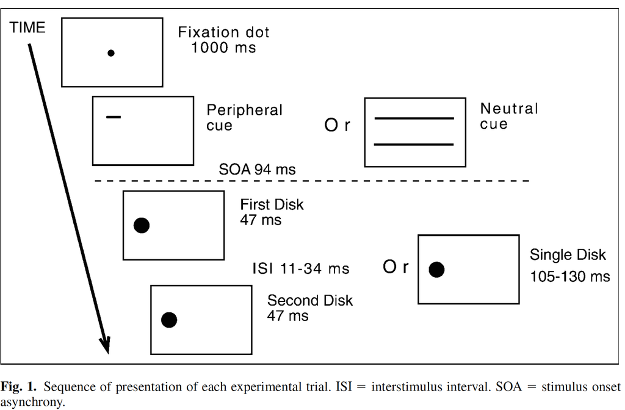

**[Fig.1. adpated from the original paper]**

### Experimetnal Code

Due to the requirement of precise timing of my project, I coded my experiment using MATLAB psychtoolbox.

Ths link for the exerpeimental code is posted in the github

[figure not shown]

###Analysis Plan

No mention of participant and data exclusion in the origianl paper.

Dependent Variables:

**Key Analysis:**

- Differences between cued and uncued trials
- Interaction effect of Cuing X Eccentricity
- The effect of interstimulus interval (ISI)

###Differences from Original Study

### Methods Addendum (Post Data Collection)

#### Differences from pre-data collection methods plan

##Results

### Data preparation

Data preparation following the analysis plan.

```r
####Load Relevant Libraries and Functions

library(tidyverse)
```

```r
library(ggplot2)
library(ggthemes)
library(psycho)
####Import data

d <- read_csv("sptioTemporal.csv")
head(d)
```

```
## # A tibble: 6 x 9
##     cue numFlash targetLoc   ISI response      RT accuracy sub   SDT
##   <dbl>    <dbl>     <dbl> <dbl>    <dbl>   <dbl>    <dbl> <chr> <chr>
## 1     0        1         3    23        1 0.00315        1 att   CR
## 2     1        2        13    23        2 0.00476        1 att   HI
## 3     1        2        16    11        1 0.00332        0 att   MI
## 4     1        2         0    11        1 0.00188        0 att   MI
## 5     1        2        13    35        2 0.00212        1 att   HI
## 6     1        1         3    23        1 0.00171        1 att   CR
```

```r
#### Prepare data for analysis - create columns etc.

d[d$cue==1,]$cue = 'cued'
d[d$cue==0,]$cue = 'netrual'

d <- d %>% mutate(
  cue = factor(cue), targetLoc = factor(targetLoc), ISI = factor(ISI)
)
```

```r
d %>%
  group_by(numFlash,sub) %>%
  summarize(AvgAccuracy = mean(accuracy)) # the na.rm tells R to ignore NA values
```

```
## # A tibble: 4 x 3
## # Groups:   numFlash [2]
##   numFlash sub   AvgAccuracy
##      <dbl> <chr>       <dbl>
## 1        1 att         0.984
## 2        1 kis         0.935
## 3        2 att         0.560
## 4        2 kis         0.829
```

```r
dp <- d %>% group_by(sub,cue,targetLoc,ISI) %>% summarize(nHit = sum(SDT == 'HI' ), nFA = sum(SDT == 'FA' ), nMiss = sum(SDT == 'MI' ), nCR = sum(SDT == 'CR' ), dPrime= dprime(nHit, nFA, nMiss, nCR)$dprime, criterion=dprime(nHit, nFA, nMiss, nCR)$c) #
dp
```

```
## # A tibble: 60 x 10
## # Groups:   sub, cue, targetLoc [20]
##    sub   cue   targetLoc ISI    nHit   nFA nMiss   nCR dPrime criterion
##    <chr> <fct> <fct>     <fct> <int> <int> <int> <int>  <dbl>     <dbl>
##  1 att   cued  0         11        0     1    12    11 -0.566     1.50
##  2 att   cued  0         23        2     0    10    12  0.890     1.34
##  3 att   cued  0         35        8     0     4    12  2.12      0.728
##  4 att   cued  3         11        0     0    12    12  0         1.79
##  5 att   cued  3         23        2     0    10    12  0.890     1.34
##  6 att   cued  3         35       10     0     2    12  2.55      0.511
##  7 att   cued  9         11        3     0     9    12  1.14      1.22
##  8 att   cued  9         23        8     0     4    12  2.12      0.728
##  9 att   cued  9         35       11     0     1    12  2.83      0.371
## 10 att   cued  13        11        4     0     8    12  1.36      1.11
## # … with 50 more rows
```

```r
dplot_cue <- d %>% group_by(sub,cue) %>% summarize(nHit = sum(SDT == 'HI' ), nFA = sum(SDT == 'FA' ), nMiss = sum(SDT == 'MI' ), nCR = sum(SDT == 'CR' ), dPrime= dprime(nHit, nFA, nMiss, nCR)$dprime, criterion=dprime(nHit, nFA, nMiss, nCR)$c) #
dplot_cue
```

```
## # A tibble: 4 x 8
## # Groups:   sub [2]
##   sub   cue      nHit   nFA nMiss   nCR dPrime criterion
##   <chr> <fct>   <int> <int> <int> <int>  <dbl>     <dbl>
## 1 att   cued      105     1   111   215   2.43    1.25
## 2 att   netrual   137     6    79   210   2.22    0.772
## 3 kis   cued      169     8    47   208   2.53    0.496
## 4 kis   netrual   189    20    27   196   2.45    0.0913
```

```r
dplot_ISI <- d %>% group_by(sub,cue,ISI) %>% summarize(nHit = sum(SDT == 'HI' ), nFA = sum(SDT == 'FA' ), nMiss = sum(SDT == 'MI' ), nCR = sum(SDT == 'CR' ), dPrime= dprime(nHit, nFA, nMiss, nCR)$dprime, criterion=dprime(nHit, nFA, nMiss, nCR)$c) #

dplot_ISI <- dplot_ISI %>% group_by(cue,ISI)  %>% summarize(`d'` = mean(dPrime))

dplot_ecc <- d %>% group_by(sub,cue,targetLoc) %>% summarize(nHit = sum(SDT == 'HI' ), nFA = sum(SDT == 'FA' ), nMiss = sum(SDT == 'MI' ), nCR = sum(SDT == 'CR' ), dPrime= dprime(nHit, nFA, nMiss, nCR)$dprime, criterion=dprime(nHit, nFA, nMiss, nCR)$c)

dplot_ecc <- dplot_ecc %>% group_by(cue,targetLoc)  %>% summarize(`d'` = mean(dPrime))
```

### Confirmatory analysis

The analyses as specified in the analysis plan.

Following the original paper:

“A within-observers three-way analysis of variance (ANOVA; Cuing x Eccentricity x ISI) was performed on the accuracy (d’) and RT data collected on trials with correct responses.”

3 way ANOVA anova was performed.

```r
# 3-way Anova
Result <- aov(dPrime ~ cue * targetLoc * ISI, data = dp)
summary(Result)
```

```
##                   Df Sum Sq Mean Sq F value   Pr(>F)
## cue                1  0.111   0.111   0.197   0.6606
## targetLoc          4  7.085   1.771   3.151   0.0282 *
## ISI                2 27.423  13.712  24.392 5.13e-07 ***
## cue:targetLoc      4  0.344   0.086   0.153   0.9602
## cue:ISI            2  0.823   0.412   0.732   0.4893
## targetLoc:ISI      8  2.862   0.358   0.636   0.7410
## cue:targetLoc:ISI  8  0.452   0.056   0.100   0.9989
## Residuals         30 16.864   0.562
## ---
## Signif. codes:  0 '***' 0.001 '**' 0.01 '*' 0.05 '.' 0.1 ' ' 1
```

The original paper found: - Significant main effect of cuing: F(1,17)=8.01 p<.01 - No significant interactions: Cuing X ISI, Cuing X Eccentricity, and ISI X Eccentricity - But the performance decrement in the cued trials was more pronounced for shorter ISIs (i.e., when a higher temporal resolution is required) than for longer ISIs and for more central, compared with more peripheral, eccentricities (Figs. 2b–2d, respectively). - Small but significant differences in response bias(c) between cueing conditions. - No significant effect of RT

This project compared the findings of above mentioned results of the original paper.

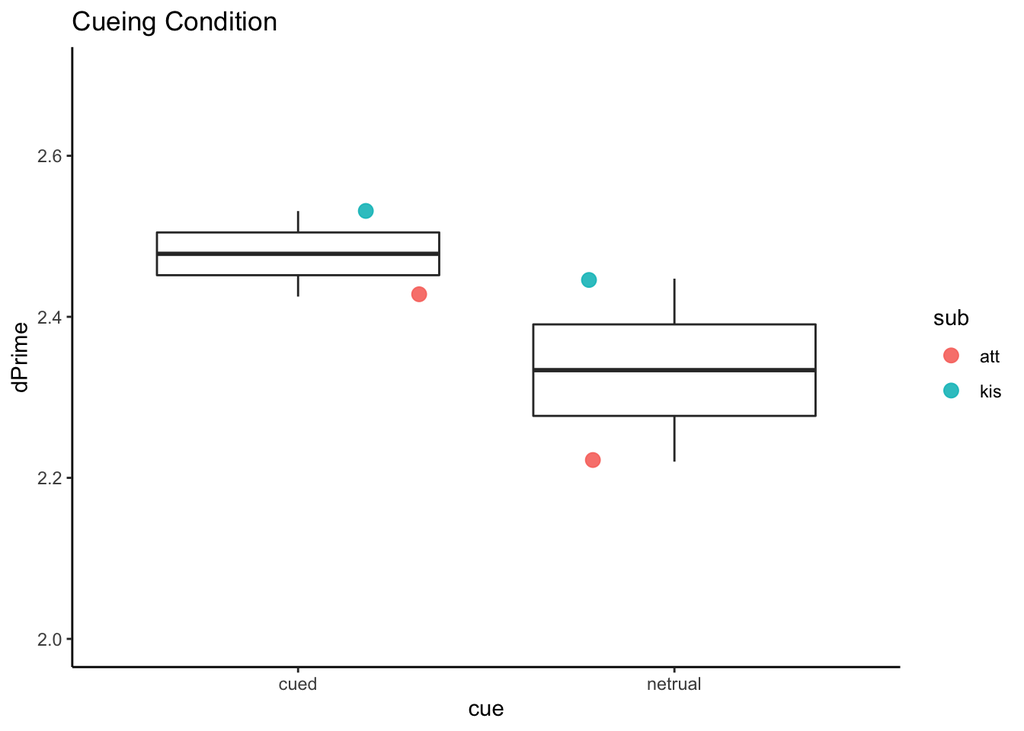

```r
ggplot(dplot_cue, aes(x=cue, y=dPrime))+
  geom_boxplot() +
  geom_jitter((aes(colour = sub)), size=3, alpha=0.9) +
  ggtitle("Cueing Condition") +
  coord_cartesian(ylim=c(2, 2.7)) +
  theme_classic()
```

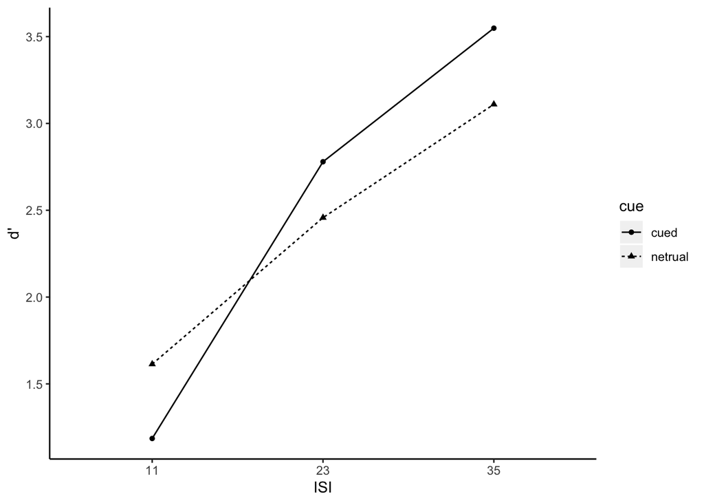

```r
myplot <- ggplot(dplot_ISI, aes(x=ISI, y=`d'`, group=cue)) +
  geom_line(aes(linetype=cue))+
  geom_point(aes(shape=cue))

myplot + theme(panel.grid.major = element_blank(), panel.grid.minor = element_blank(),
panel.background = element_blank(), axis.line = element_line(colour = "black"))
```

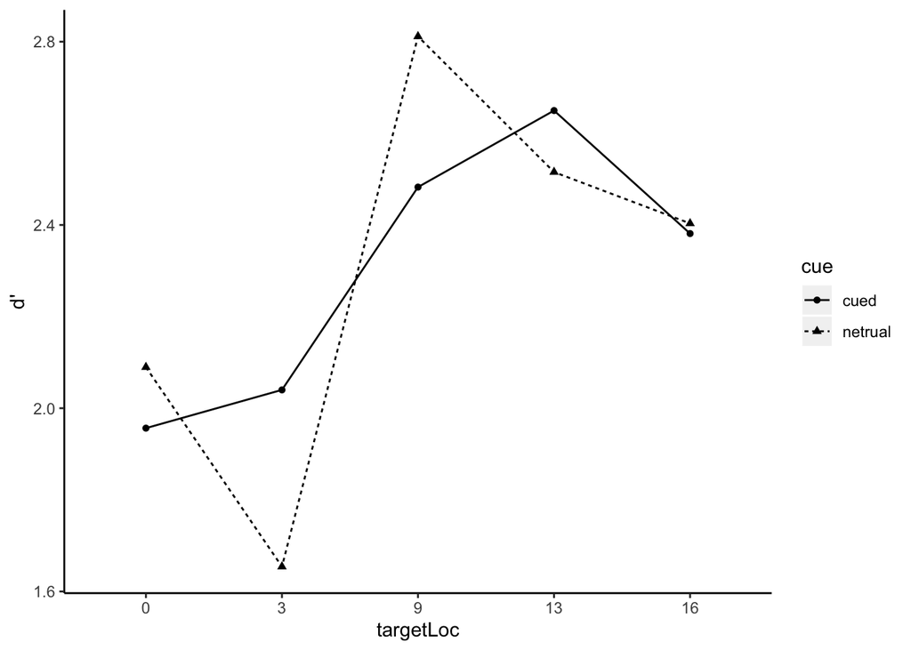

```r
myplot <- ggplot(dplot_ecc, aes(x=targetLoc, y=`d'`, group=cue)) +
  geom_line(aes(linetype=cue))+
  geom_point(aes(shape=cue))

myplot + theme(panel.grid.major = element_blank(), panel.grid.minor = element_blank(),
panel.background = element_blank(), axis.line = element_line(colour = "black"))
```

###Exploratory analyses